# Examen 10 Julio

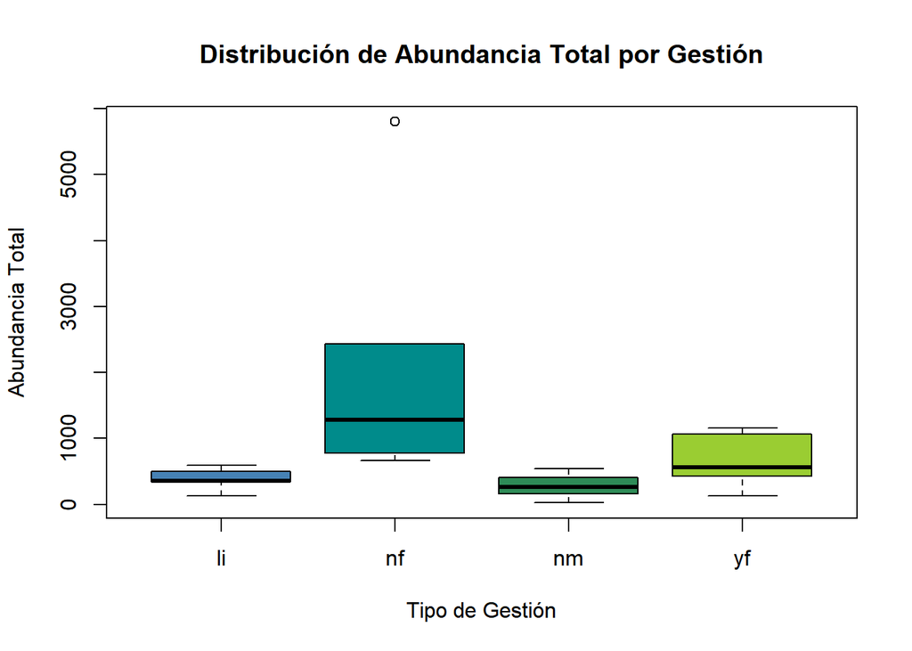

```r
abundancias<-lemin[,4:32]
lemin$TotalAbund <- rowSums(abundancias)
boxplot(TotalAbund ~ manag, data = lemin,
        main = "Distribución de Abundancia Total por Gestión",
        xlab = "Tipo de Gestión", ylab = "Abundancia Total",
        col = c("steelblue", "darkcyan", "seagreen", "yellowgreen"))
```

Los boxplots muestran que el grupo de nf es un poco más diferente a los otros 3, los cuales son muy parecidos entre si.

```r
canon<-cca(abundancias~manag,data=lemin)
anova(canon)
```

```
## Permutation test for cca under reduced model
## Permutation: free
## Number of permutations: 999
##
## Model: cca(formula = abundancias ~ manag, data = lemin)
##          Df ChiSquare      F Pr(>F)
## Model     3   0.32057 2.0594  0.049 *
## Residual 19   0.98587
## ---
## Signif. codes:  0 '***' 0.001 '**' 0.01 '*' 0.05 '.' 0.1 ' ' 1
```

```r
summary(canon)
```

```
##
## Call:
## cca(formula = abundancias ~ manag, data = lemin)
##
## Partitioning of scaled Chi-square:
##               Inertia Proportion
## Total          1.3064     1.0000
## Constrained    0.3206     0.2454
## Unconstrained  0.9859     0.7546
##
## Eigenvalues, and their contribution to the scaled Chi-square
##
## Importance of components:
##                         CCA1    CCA2    CCA3    CA1    CA2    CA3     CA4
## Eigenvalue            0.2127 0.06530 0.04257 0.1980 0.1422 0.1361 0.11520
## Proportion Explained  0.1628 0.04998 0.03259 0.1515 0.1088 0.1042 0.08818
## Cumulative Proportion 0.1628 0.21279 0.24538 0.3969 0.5057 0.6099 0.69808
##                           CA5     CA6     CA7     CA8     CA9    CA10    CA11
## Eigenvalue            0.09440 0.07996 0.07313 0.03627 0.02755 0.02111 0.01987
## Proportion Explained  0.07226 0.06120 0.05597 0.02776 0.02109 0.01616 0.01521
## Cumulative Proportion 0.77034 0.83154 0.88752 0.91528 0.93636 0.95252 0.96773
##                          CA12     CA13     CA14     CA15     CA16     CA17
## Eigenvalue            0.01527 0.009235 0.005371 0.004777 0.003992 0.002448
## Proportion Explained  0.01169 0.007069 0.004111 0.003657 0.003056 0.001874
## Cumulative Proportion 0.97942 0.986490 0.990601 0.994258 0.997313 0.999187
##                            CA18      CA19
## Eigenvalue            0.0007411 0.0003214
## Proportion Explained  0.0005673 0.0002460
## Cumulative Proportion 0.9997540 1.0000000
##
## Accumulated constrained eigenvalues
## Importance of components:
##                         CCA1   CCA2    CCA3
## Eigenvalue            0.2127 0.0653 0.04257
## Proportion Explained  0.6635 0.2037 0.13280
## Cumulative Proportion 0.6635 0.8672 1.00000
```

El anova nos indica que si existe una diferencia entre los manejos, sin embargo, esta es apenas significativa con su valor de 0.04, por otra parte el resumen del análisis de correlación canónica nos indica que aproximadamente el 24% de las diferencias entre los estanques se dan por el tipo de manejo y por otra parte el 75% de estas diferencias son naturales, es la variabilidad natural que existe dentro de estos estanques.  
Además con el CCA1 y CCA2 juntos explican aproximadamente el 86% de las diferencias.

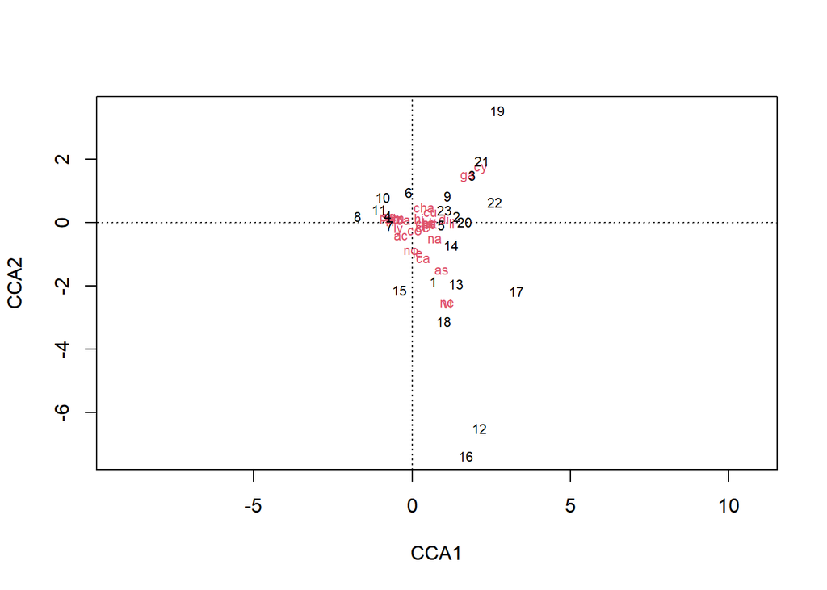

```r
plot(canon, display = c("species", "sites"), type = "text")
```

Lo que este gráfico muestra son los estanques representados con números negros mientras que las especies están con letras rojas. Aquí se pueden observar algunas agrupaciones como por ejemplo los estanques 9-23-2-20-5-14, 21-3-22, 15-1-13-18 y 12-16.

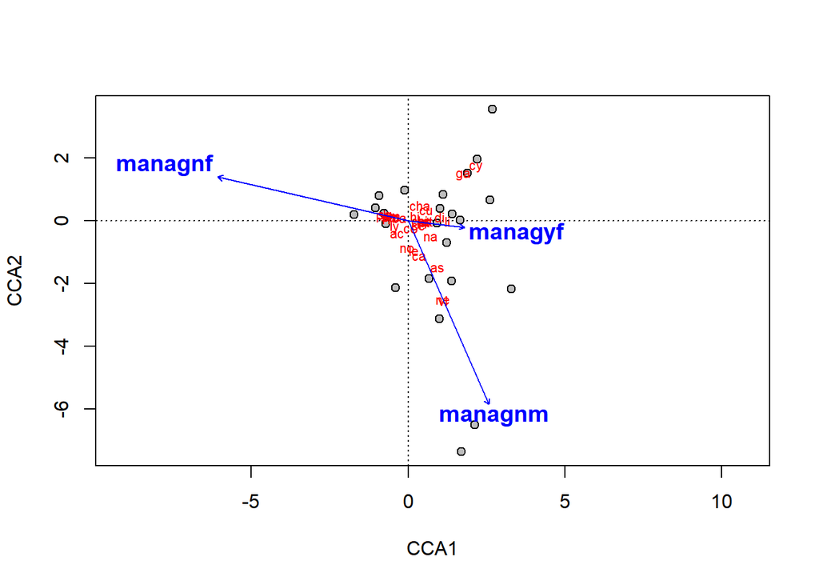

```r
plot(canon, type = "n")
points(canon, display = "sites", pch = 21, bg = "gray")
text(canon, display = "species", col = "red", cex = 0.7)
text(canon, display = "bp", col = "blue", cex = 1.2, font = 2)
```

Lo que muestra el gráfico es basicamente lo mismo que el pasado pero esta vez los puntos grises son los estanques, las letras rojas son las especies y esta vez se integran los tipos de manejo en la gráfica.

23. **La «Teoría de la conducta planificada» es una teoría sobre por qué las personas realizan actividad física. La serie de datos “SEM.txt” reúne información sobre componentes relacionadas a la voluntad de hacer ejercicio. Las actitudes se refieren al grado en que una persona tiene una opinión favorable sobre hacer ejercicio; las normas subjetivas se refieren a si considera que otras personas, cuyas opiniones valora, creen que el ejercicio es algo positivo; y el control conductual percibido se refiere al grado en que considera que realizar ejercicio está bajo su control. Las intenciones se refieren a si una persona tiene la intención de hacer ejercicio, y la conducta es una medida del grado en que efectivamente lo realizó. Cada constructo se mide mediante cuatro ítems. Construye un modelo de ecuaciones estructurales para medir que relación tienen las variables endógenas y exógenas.** (25puntos)

Para esto se tiene que hacer un modelo de ecuaciones estructurales

```r
sem1<-read.table("C:/Users/100032608/Downloads/SEM_1.txt",header=TRUE)
summary(sem1)
```

```
##    attitude1       attitude2       attitude3       attitude4
##  Min.   :1.000   Min.   :1.000   Min.   :1.000   Min.   :1.000
##  1st Qu.:3.000   1st Qu.:3.000   1st Qu.:3.000   1st Qu.:3.000
##  Median :4.000   Median :4.000   Median :4.000   Median :4.000
##  Mean   :4.104   Mean   :4.191   Mean   :4.012   Mean   :4.173
##  3rd Qu.:5.000   3rd Qu.:5.000   3rd Qu.:5.000   3rd Qu.:5.000
##  Max.   :7.000   Max.   :7.000   Max.   :7.000   Max.   :7.000
##       SN1             SN2             SN3             SN4
##  Min.   :1.000   Min.   :1.000   Min.   :1.000   Min.   :1.000
##  1st Qu.:3.000   1st Qu.:3.000   1st Qu.:3.000   1st Qu.:3.000
##  Median :4.000   Median :4.000   Median :4.000   Median :4.000
##  Mean   :3.999   Mean   :3.766   Mean   :4.164   Mean   :3.907
##  3rd Qu.:5.000   3rd Qu.:5.000   3rd Qu.:5.000   3rd Qu.:5.000
##  Max.   :7.000   Max.   :7.000   Max.   :7.000   Max.   :7.000
##       PBC1            PBC2           PBC3            PBC4            int1
##  Min.   :1.000   Min.   :1.00   Min.   :1.000   Min.   :1.000   Min.   :1.000
##  1st Qu.:3.000   1st Qu.:3.00   1st Qu.:3.000   1st Qu.:3.000   1st Qu.:3.000
##  Median :4.000   Median :4.00   Median :4.000   Median :4.000   Median :4.000
##  Mean   :3.809   Mean   :3.89   Mean   :3.747   Mean   :4.103   Mean   :4.208
##  3rd Qu.:5.000   3rd Qu.:5.00   3rd Qu.:4.000   3rd Qu.:5.000   3rd Qu.:5.000
##  Max.   :7.000   Max.   :7.00   Max.   :7.000   Max.   :7.000   Max.   :7.000
##       int2            int3            int4            int5
##  Min.   :1.000   Min.   :1.000   Min.   :1.000   Min.   :1.000
##  1st Qu.:3.000   1st Qu.:3.000   1st Qu.:3.000   1st Qu.:4.000
##  Median :4.000   Median :4.000   Median :4.000   Median :4.000
##  Mean   :3.826   Mean   :4.188   Mean   :3.879   Mean   :4.499
##  3rd Qu.:4.000   3rd Qu.:5.000   3rd Qu.:5.000   3rd Qu.:5.000
##  Max.   :7.000   Max.   :7.000   Max.   :7.000   Max.   :7.000
##       beh1            beh2            beh3            beh4
##  Min.   :1.000   Min.   :1.000   Min.   :1.000   Min.   :1.000
##  1st Qu.:3.000   1st Qu.:3.250   1st Qu.:3.000   1st Qu.:3.000
##  Median :4.000   Median :4.000   Median :4.000   Median :4.000
##  Mean   :3.872   Mean   :4.288   Mean   :4.206   Mean   :4.136
##  3rd Qu.:5.000   3rd Qu.:5.000   3rd Qu.:5.000   3rd Qu.:5.000
##  Max.   :7.000   Max.   :7.000   Max.   :7.000   Max.   :7.000
```

```r
tpb_model <- '
  Actitud =~ attitude1 + attitude2 + attitude3 + attitude4
  SN      =~ SN1 + SN2 + SN3 + SN4
  PBC     =~ PBC1 + PBC2 + PBC3 + PBC4
  Int     =~ int1 + int2 + int3 + int4 + int5
  Conducta =~ beh1 + beh2 + beh3 + beh4

  Int ~ Actitud + SN + PBC
  Conducta ~ Int + PBC
'
fit <- sem(tpb_model, data = sem1)
summary(fit, standardized = TRUE, fit.measures = TRUE)
```

```
## lavaan 0.6-21 ended normally after 42 iterations
##
##   Estimator                                         ML
##   Optimization method                           NLMINB
##   Number of model parameters                        50
##
##   Number of observations                           890
##
## Model Test User Model:
##
##   Test statistic                               286.523
##   Degrees of freedom                               181
##   P-value (Chi-square)                           0.000
##
## Model Test Baseline Model:
##
##   Test statistic                              3621.666
##   Degrees of freedom                               210
##   P-value                                        0.000
##
## User Model versus Baseline Model:
##
##   Comparative Fit Index (CFI)                    0.969
##   Tucker-Lewis Index (TLI)                       0.964
##
## Loglikelihood and Information Criteria:
##
##   Loglikelihood user model (H0)             -27390.532
##   Loglikelihood unrestricted model (H1)     -27247.271
##
##   Akaike (AIC)                               54881.065
##   Bayesian (BIC)                             55120.626
##   Sample-size adjusted Bayesian (SABIC)      54961.836
##
## Root Mean Square Error of Approximation:
##
##   RMSEA                                          0.026
##   90 Percent confidence interval - lower         0.020
##   90 Percent confidence interval - upper         0.031
##   P-value H_0: RMSEA <= 0.050                    1.000
```

[output cut: 72 more lines]

```
##    .PBC4              0.910    0.055   16.546    0.000    0.910    0.661
##    .int1              1.022    0.055   18.600    0.000    1.022    0.666
##    .int2              0.507    0.034   14.904    0.000    0.507    0.450
##    .int3              0.834    0.046   18.147    0.000    0.834    0.629
##    .int4              0.658    0.042   15.624    0.000    0.658    0.481
##    .int5              0.802    0.043   18.842    0.000    0.802    0.688
##    .beh1              0.955    0.056   17.138    0.000    0.955    0.672
##    .beh2              0.918    0.055   16.565    0.000    0.918    0.642
##    .beh3              0.844    0.055   15.363    0.000    0.844    0.587
##    .beh4              0.959    0.058   16.474    0.000    0.959    0.637
##     Actitud           0.471    0.068    6.925    0.000    1.000    1.000
##     SN                0.416    0.059    7.100    0.000    1.000    1.000
##     PBC               0.471    0.057    8.274    0.000    1.000    1.000
##    .Int               0.369    0.045    8.102    0.000    0.721    0.721
##    .Conducta          0.317    0.043    7.338    0.000    0.679    0.679
```

Con el resumen del modelo muestra un valor de CFI mayor a 0.9 lo cual significa que tiene un buen ajuste a los datos, de igual manera el RMSEA es menor a 0.08 lo cual significa que no hay diferencias notables entre el modelo y los datos observados.  
Con las variables latentes todas tienen un valor de p igual a 0 lo que significa que está bien.  
En las regresiones, los valores de p son iguales a 0 lo que indica que son resultados significativos.